# Bank_Loans_Modelling

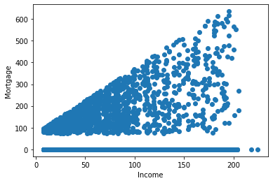

```python
plt.scatter(df['Income'],df['Mortgage'])
plt.xlabel('Income')
plt.ylabel('Mortgage')
```

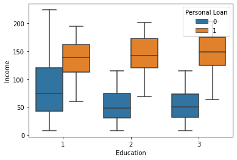

```python
sns.boxplot(x='Education',y='Income',hue='Personal Loan',data=df)
```

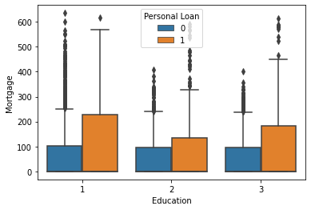

```python
sns.boxplot(x="Education", y='Mortgage', hue="Personal Loan", data=df)
```

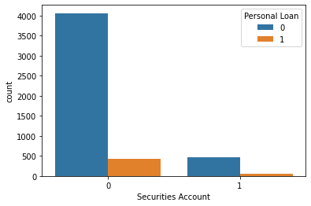

```python
sns.countplot(x="Securities Account", data=df,hue="Personal Loan")
```

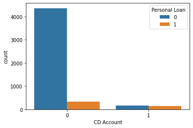

```python
sns.countplot(x='CD Account',data=df,hue='Personal Loan')
```

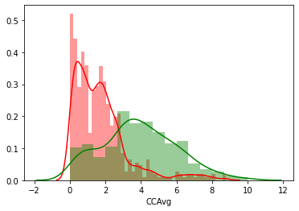

```python
sns.distplot( df[df['Personal Loan'] == 0]['CCAvg'], color = 'r')
sns.distplot( df[df['Personal Loan'] == 1]['CCAvg'], color = 'g')
```

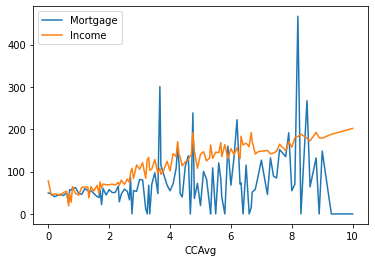

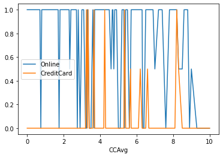

```python
df_group = df.groupby('CCAvg').mean()[['Mortgage','Income']]
df_group.plot.line()
df_group2 = df.groupby('CCAvg').median()[['Online','CreditCard']]
df_group2.plot.line()
```

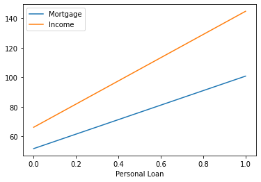

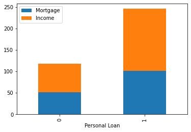

```python
df_group3 = df.groupby('Personal Loan').mean()[['Mortgage','Income']]
df_group3.plot.line()
df_group3.plot.bar(stacked=True)
```

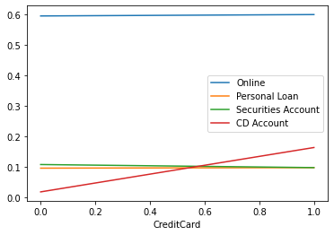

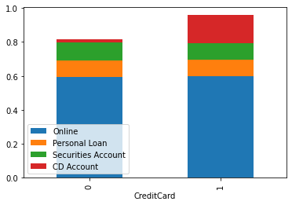

```python
df_group4 = df.groupby('CreditCard').mean()[['Online','Personal Loan','Securities Account','CD Account']]
df_group4.plot.line()
df_group4.plot.bar(stacked=True)
```

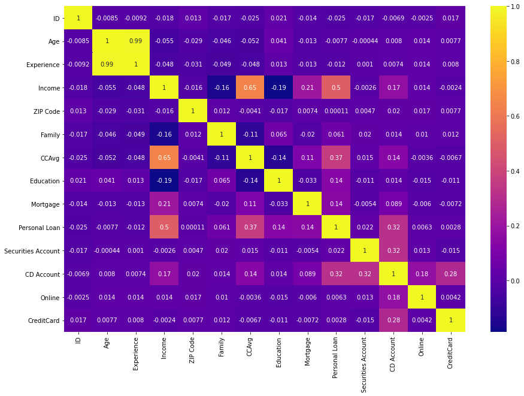

```python
fig,ax = plt.subplots(figsize=(15,10))
sns.heatmap(df.corr() , cmap='plasma' , annot=True)
```

**(5) Normalise your data and split the data into training and test set in the ratio of 70:30 respectively**

```python
from sklearn.model_selection import train_test_split
target = 'Personal Loan'
df_x = df.drop(target,axis='columns',inplace=False)
df_y = df[target]

x_train,x_test,y_train,y_test = train_test_split(df_x, df_y,test_size=0.30,random_state=0,stratify=df_y)
```

**(4) Apply necessary transformations for the feature variables**

```python
def quick_analysis(df):
 print('Data Types:')
 print(df.dtypes)
 print('Rows and Columns:')
 print(df.shape)
 print('Column Names:')
 print(df.columns)
 print('Null Values:')
 print(df.apply(lambda x: sum(x.isnull()) / len(df)))


quick_analysis(df)
```

```
Data Types:
ID                      int64
Age                     int64
Experience            float64
Income                  int64
ZIP Code                int64
Family                  int64
CCAvg                 float64
Education               int64
Mortgage                int64
Personal Loan           int64
Securities Account      int64
CD Account              int64
Online                  int64
CreditCard              int64
dtype: object
Rows and Columns:
(5000, 14)
Column Names:
Index(['ID', 'Age', 'Experience', 'Income', 'ZIP Code', 'Family', 'CCAvg',
       'Education', 'Mortgage', 'Personal Loan', 'Securities Account',
       'CD Account', 'Online', 'CreditCard'],
      dtype='object')
Null Values:
ID                    0.0000
Age                   0.0000
Experience            0.0058
Income                0.0000
ZIP Code              0.0000
Family                0.0000
CCAvg                 0.0000
Education             0.0000
Mortgage              0.0000
Personal Loan         0.0000
Securities Account    0.0000
CD Account            0.0000
Online                0.0000
CreditCard            0.0000
dtype: float64
```

```python
df.describe()
```

|  | ID | Age | Experience | Income | ZIP Code | Family | CCAvg | Education | Mortgage | Personal Loan | Securities Account | CD Account | Online | CreditCard |
| --- | --- | --- | --- | --- | --- | --- | --- | --- | --- | --- | --- | --- | --- | --- |
| count | 5000.000000 | 5000.000000 | 4971.000000 | 5000.000000 | 5000.000000 | 5000.000000 | 5000.000000 | 5000.000000 | 5000.000000 | 5000.000000 | 5000.000000 | 5000.00000 | 5000.000000 | 5000.000000 |
| mean | 2500.500000 | 45.338400 | 20.244015 | 73.774200 | 93152.503000 | 2.396400 | 1.937913 | 1.881000 | 56.498800 | 0.096000 | 0.104400 | 0.06040 | 0.596800 | 0.294000 |
| std | 1443.520003 | 11.463166 | 11.357967 | 46.033729 | 2121.852197 | 1.147663 | 1.747666 | 0.839869 | 101.713802 | 0.294621 | 0.305809 | 0.23825 | 0.490589 | 0.455637 |
| min | 1.000000 | 23.000000 | 0.000000 | 8.000000 | 9307.000000 | 1.000000 | 0.000000 | 1.000000 | 0.000000 | 0.000000 | 0.000000 | 0.00000 | 0.000000 | 0.000000 |
| 25% | 1250.750000 | 35.000000 | 10.000000 | 39.000000 | 91911.000000 | 1.000000 | 0.700000 | 1.000000 | 0.000000 | 0.000000 | 0.000000 | 0.00000 | 0.000000 | 0.000000 |
| 50% | 2500.500000 | 45.000000 | 20.000000 | 64.000000 | 93437.000000 | 2.000000 | 1.500000 | 2.000000 | 0.000000 | 0.000000 | 0.000000 | 0.00000 | 1.000000 | 0.000000 |
| 75% | 3750.250000 | 55.000000 | 30.000000 | 98.000000 | 94608.000000 | 3.000000 | 2.500000 | 3.000000 | 101.000000 | 0.000000 | 0.000000 | 0.00000 | 1.000000 | 1.000000 |
| max | 5000.000000 | 67.000000 | 43.000000 | 224.000000 | 96651.000000 | 4.000000 | 10.000000 | 3.000000 | 635.000000 | 1.000000 | 1.000000 | 1.00000 | 1.000000 | 1.000000 |

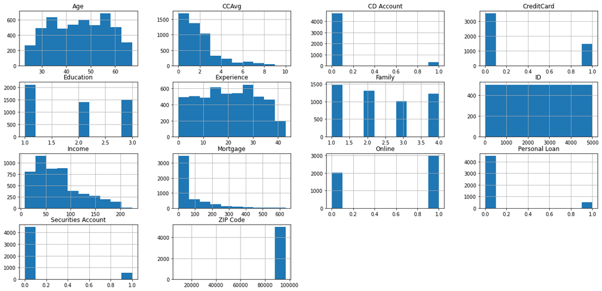

```python
df[df.dtypes[(df.dtypes=="float64")|(df.dtypes=="int64")].index.values].hist(figsize=[21,10])
plt.show()
```

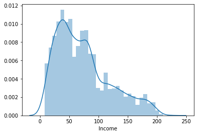

```python
sns.distplot(df.Income)
```

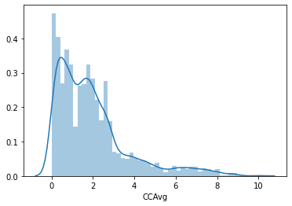

```python
sns.distplot(df.CCAvg)
```

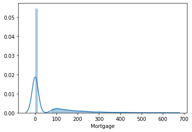

```python
sns.distplot(df.Mortgage)
```

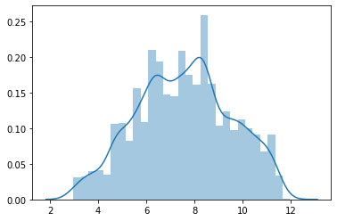

```python
from sklearn.preprocessing import PowerTransformer as pt

pwt = pt(method="yeo-johnson" , standardize=False)

pwt.fit(df_x["Income"].values.reshape(-1,1))
temp = pwt.transform(df_x["Income"].values.reshape(-1,1))
sns.distplot(temp)
plt.show()
```

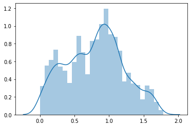

```python
from sklearn.preprocessing import PowerTransformer as pt

pwt = pt(method="yeo-johnson" , standardize=False)

pwt.fit(df_x["CCAvg"].values.reshape(-1,1))
temp = pwt.transform(df_x["CCAvg"].values.reshape(-1,1))
sns.distplot(temp)
```

**(6) Use the Logistic Regression model to predict the likelihood of a customer buying personal loans**

```python
from sklearn.linear_model import LogisticRegression
from sklearn.metrics import accuracy_score
from sklearn.model_selection import train_test_split
```

```python
#In it our target is Personal Loan column so for x_dataset just drop this and for y_dataset take Personal Loan column
target = 'Personal Loan'
df_x = df.drop(target,axis='columns',inplace=False)
df_y = df[target]

x_train,x_test,y_train,y_test = train_test_split(df_x, df_y,test_size=0.30,random_state=100,stratify=df_y)
```

```python
#check if their is null value exist
df.isnull().sum().sort_values(ascending = False)
```

```
Experience            29
CreditCard             0
Online                 0
CD Account             0
Securities Account     0
Personal Loan          0
Mortgage               0
Education              0
CCAvg                  0
Family                 0
ZIP Code               0
Income                 0
Age                    0
ID                     0
dtype: int64
```

```python
#if null value is their then drop
df = df.dropna(subset=['Experience'])
df.isnull().sum().sort_values(ascending = False)
```

```
CreditCard            0
Online                0
CD Account            0
Securities Account    0
Personal Loan         0
Mortgage              0
Education             0
CCAvg                 0
Family                0
ZIP Code              0
Income                0
Experience            0
Age                   0
ID                    0
dtype: int64
```

```python
target = 'Personal Loan'
df_x = df.drop(target,axis='columns',inplace=False)
df_y = df[target]


#so perform Logistic Regression with the split of 70:30 in training and testing data respectively
x_train,x_test,y_train,y_test = train_test_split(df_x, df_y,test_size=0.30,random_state=100,stratify=df_y)
L_R = LogisticRegression(max_iter=1000)
L_R.fit(x_train,y_train)
```

```
LogisticRegression(C=1.0, class_weight=None, dual=False, fit_intercept=True,
                   intercept_scaling=1, l1_ratio=None, max_iter=1000,
                   multi_class='auto', n_jobs=None, penalty='l2',
                   random_state=None, solver='lbfgs', tol=0.0001, verbose=0,
                   warm_start=False)
```

```python
#Accuracy for the model
y_pred = L_R.predict(x_test)
print("Accuracy of logistic regression classifier on test set :",accuracy_score(y_test,y_pred)*100)
```

```
Accuracy of logistic regression classifier on test set : 94.16890080428955
```

```python
print("Testing Accuracy",L_R.fit(x_train,y_train).score(x_test,y_test)*100)
```

```
Testing Accuracy 94.16890080428955
```

```python
print("Training Accuracy" , L_R.fit(x_train,y_train).score(x_train,y_train)*100)
```

```
Training Accuracy 93.7625754527163
```

**(7) Print all the metrics related for evaluating the model performance**

```python
#classification report contains all major aspect which are the very useful for analysis the performance of model
from sklearn.metrics import classification_report
print(classification_report(y_test, y_pred))
```

```
              precision    recall  f1-score   support

           0       0.96      0.98      0.97      1348
           1       0.76      0.58      0.66       144

    accuracy                           0.94      1492
   macro avg       0.86      0.78      0.81      1492
weighted avg       0.94      0.94      0.94      1492
```

```python
from sklearn.metrics import confusion_matrix
confusion_matrix = confusion_matrix(y_test, y_pred)
print(confusion_matrix)
```

```
[[1321   27]
 [  60   84]]
```

```
Confusion matrix, without normalization
[[1326   22]
 [  69   75]]
Normalized confusion matrix
[[0.98 0.02]
 [0.48 0.52]]
```

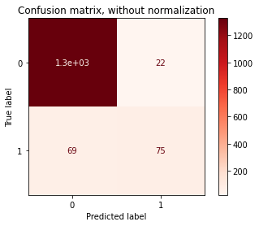

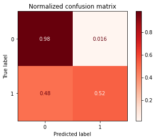

```python
#show the confusion matrix with and without normalization
from sklearn.metrics import plot_confusion_matrix
classifier = LogisticRegression(max_iter=1000,C=0.01).fit(x_train, y_train)

np.set_printoptions(precision=2)

# Plot non-normalized confusion matrix
titles_options = [("Confusion matrix, without normalization", None),
                  ("Normalized confusion matrix", 'true')]
for title, normalize in titles_options:
    disp = plot_confusion_matrix(classifier, x_test, y_test,
                                 cmap=plt.cm.Reds,
                                 normalize=normalize)
    disp.ax_.set_title(title)

    print(title)
    print(disp.confusion_matrix)

plt.show()
```

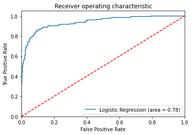

```python
#ROC ( Receiver Operating Characteristic ) Curve

#a good classifier stays as far away from that line as possible (toward the top-left corner)
from sklearn.metrics import roc_auc_score
from sklearn.metrics import roc_curve
logit_roc_auc = roc_auc_score(y_test, L_R.predict(x_test))
fpr, tpr, thresholds = roc_curve(y_test, L_R.predict_proba(x_test)[:,1])
plt.figure()
plt.plot(fpr, tpr, label='Logistic Regression (area = %0.2f)' % logit_roc_auc)
plt.plot([0, 1], [0, 1],'r--')
plt.xlim([0.0, 1.0])
plt.ylim([0.0, 1.05])
plt.xlabel('False Positive Rate')
plt.ylabel('True Positive Rate')
plt.title('Receiver operating characteristic')
plt.legend(loc="lower right")
plt.savefig('Log_ROC')
plt.show()
```

```python
pred_1_test_x = L_R.predict(x_test)
pred_1_train_x = L_R.predict(x_train)

from sklearn.metrics import recall_score,precision_score,f1_score,roc_auc_score
print("Recall : ",recall_score(y_test , pred_1_test_x))
print("Precision : ", precision_score(y_test , pred_1_test_x))
print("F1 Score : ", f1_score(y_test , pred_1_test_x))
print("Roc Auc Score : ", roc_auc_score(y_test , pred_1_test_x))

#Normal Logistic Regression give the accuracy 94% with 58% Recall and 78% Roc.
```

```
Recall :  0.5833333333333334
Precision :  0.7567567567567568
F1 Score :  0.6588235294117648
Roc Auc Score :  0.7816518298714146
```

**(8) Build various other classification algorithms and compare their performance**

```python
#AFTER APPLYING STANDARDIZATION IN LOGISTIC REGRESSION

from sklearn import preprocessing

col_names = df.columns
scaler=preprocessing.StandardScaler()
scaled_x_train=scaler.fit_transform(x_train)
scaled_x_test=scaler.fit_transform(x_test)
L_R = LogisticRegression()
L_R.fit(scaled_x_train,y_train)

from sklearn.metrics import recall_score,precision_score,f1_score,roc_auc_score,accuracy_score,confusion_matrix
from sklearn.metrics import roc_curve,auc

y_pred1 = L_R.predict(scaled_x_test)
print(classification_report(y_test,y_pred1))
print(accuracy_score(y_test,y_pred1))
print(confusion_matrix(y_test,y_pred1))

LR_prob=L_R.predict_proba(scaled_x_test)
fpr1,tpr1,thresholds1=roc_curve(y_test,LR_prob[:,1])
roc_auc1=auc(fpr1,tpr1)
print("Area under the Roc curve : %f " % roc_auc1)

pred_1_test_x = L_R.predict(scaled_x_test)
pred_1_train_x = L_R.predict(scaled_x_train)
print("Recall : ",recall_score(y_test , pred_1_test_x))
print("Precision : ", precision_score(y_test , pred_1_test_x))
print("F1 Score : ", f1_score(y_test , pred_1_test_x))
print("Roc Auc Score : ", roc_auc_score(y_test , pred_1_test_x))

# Standardization Logistic Regression give the accuracy 95% with 63% Recall and 81% Roc.
# which is better then Logistic Regression .
```

```
              precision    recall  f1-score   support

           0       0.96      0.98      0.97      1348
           1       0.81      0.64      0.72       144

    accuracy                           0.95      1492
   macro avg       0.89      0.81      0.84      1492
weighted avg       0.95      0.95      0.95      1492

0.9510723860589813
[[1327   21]
 [  52   92]]
Area under the Roc curve : 0.950137
Recall :  0.6388888888888888
Precision :  0.8141592920353983
F1 Score :  0.7159533073929961
Roc Auc Score :  0.811655126937026
```

```python
#K-Nearest Neighbor
from sklearn.metrics import roc_curve,auc
from sklearn.neighbors import KNeighborsClassifier
knn_Model=KNeighborsClassifier(n_neighbors=3)
knn_Model.fit(scaled_x_train,y_train)

y_pred=knn_Model.predict(scaled_x_test)

print(classification_report(y_test,y_pred))
print(accuracy_score(y_test,y_pred))
print(confusion_matrix(y_test,y_pred))


kNN_prob=knn_Model.predict_proba(scaled_x_test)
fpr2,tpr2,thresholds2=roc_curve(y_test,kNN_prob[:,1])
roc_auc2=auc(fpr2,tpr2)
print("Area under the Roc curve : %f " % roc_auc2)

pred_1_test_x = knn_Model.predict(scaled_x_test)
pred_1_train_x = knn_Model.predict(scaled_x_train)
print("Recall : ",recall_score(y_test , pred_1_test_x))
print("Precision : ", precision_score(y_test , pred_1_test_x))
print("F1 Score : ", f1_score(y_test , pred_1_test_x))
print("Roc Auc Score : ", roc_auc_score(y_test , pred_1_test_x))

# K-Nearest Neighbor give the accuracy 94% with 53% Recall and 76% Roc.
# which is worse then Normal Logistic Regression.
```

```
              precision    recall  f1-score   support

           0       0.95      0.99      0.97      1348
           1       0.88      0.53      0.66       144

    accuracy                           0.95      1492
   macro avg       0.91      0.76      0.82      1492
weighted avg       0.94      0.95      0.94      1492

0.9477211796246648
[[1337   11]
 [  67   77]]
Area under the Roc curve : 0.884525
Recall :  0.5347222222222222
Precision :  0.875
F1 Score :  0.6637931034482758
Roc Auc Score :  0.7632809924167491
```

```python
#NAIVE BAYES
from sklearn.naive_bayes import GaussianNB


naive_model = GaussianNB()
naive_model.fit(scaled_x_train,y_train)
y_pred=naive_model.predict(scaled_x_test)

print(classification_report(y_test,y_pred))
print(accuracy_score(y_test,y_pred))
print(confusion_matrix(y_test,y_pred))

nbm_prob=naive_model.predict_proba(scaled_x_test)
fpr3,tpr3,thresholds3=roc_curve(y_test,nbm_prob[:,1])
roc_auc3=auc(fpr3,tpr3)
print("Area under the Roc curve : %f " % roc_auc3)


pred_1_test_x = naive_model.predict(scaled_x_test)
pred_1_train_x = naive_model.predict(scaled_x_train)
print("Recall : ",recall_score(y_test , pred_1_test_x))
print("Precision : ", precision_score(y_test , pred_1_test_x))
print("F1 Score : ", f1_score(y_test , pred_1_test_x))
print("Roc Auc Score : ", roc_auc_score(y_test , pred_1_test_x))

# Naive Bayes give the accuracy 88% with 53% Recall and 72% Roc.
# which is  even worse then K-Nearest Neighbor.
```

```
              precision    recall  f1-score   support

           0       0.95      0.92      0.93      1348
           1       0.41      0.53      0.46       144

    accuracy                           0.88      1492
   macro avg       0.68      0.73      0.70      1492
weighted avg       0.90      0.88      0.89      1492

0.8806970509383378
[[1237  111]
 [  67   77]]
Area under the Roc curve : 0.920989
Recall :  0.5347222222222222
Precision :  0.4095744680851064
F1 Score :  0.463855421686747
Roc Auc Score :  0.7261890042861853
```

```python
#SUPPORT VECTOR MACHINE
from sklearn import svm
clfr=svm.SVC(C=3,kernel='rbf',probability=True)
clfr.fit(scaled_x_train,y_train)
y_pred= clfr.predict(scaled_x_test)

print(classification_report(y_test,y_pred))
print(accuracy_score(y_test,y_pred))
print(confusion_matrix(y_test,y_pred))

svm_prob=clfr.predict_proba(scaled_x_test)
fpr4,tpr4,thresholds4=roc_curve(y_test,svm_prob[:,1])
roc_auc4=auc(fpr4,tpr4)
print("Area under the Roc curve : %f " % roc_auc4)


pred_1_test_x = clfr.predict(scaled_x_test)
pred_1_train_x = clfr.predict(scaled_x_train)
print("Recall : ",recall_score(y_test , pred_1_test_x))
print("Precision : ", precision_score(y_test , pred_1_test_x))
print("F1 Score : ", f1_score(y_test , pred_1_test_x))
print("Roc Auc Score : ", roc_auc_score(y_test , pred_1_test_x))

# Support Vector Machine give the accuracy 97% with 80% Recall and 90% Roc.
# which is better then Standardization Logistic Regression.
```

```
              precision    recall  f1-score   support

           0       0.98      1.00      0.99      1348
           1       0.96      0.81      0.88       144

    accuracy                           0.98      1492
   macro avg       0.97      0.90      0.93      1492
weighted avg       0.98      0.98      0.98      1492

0.9778820375335121
[[1343    5]
 [  28  116]]
Area under the Roc curve : 0.981155
Recall :  0.8055555555555556
Precision :  0.9586776859504132
F1 Score :  0.8754716981132076
Roc Auc Score :  0.9009231783712496
```

```python
#DECISION TREE
from sklearn.tree import DecisionTreeClassifier
d_t=DecisionTreeClassifier(criterion='entropy' , random_state=1)
d_t.fit(scaled_x_train,y_train)
y_pred=d_t.predict(scaled_x_test)

print(classification_report(y_test,y_pred))
print(accuracy_score(y_test,y_pred))
print(confusion_matrix(y_test,y_pred))

dt_prob=d_t.predict_proba(scaled_x_test)
fpr5,tpr5,thresholds5=roc_curve(y_test,dt_prob[:,1])
roc_auc5=auc(fpr5,tpr5)
print("Area under the Roc curve : %f " % roc_auc5)


pred_1_test_x = d_t.predict(scaled_x_test)
pred_1_train_x = d_t.predict(scaled_x_train)
print("Recall : ",recall_score(y_test , pred_1_test_x))
print("Precision : ", precision_score(y_test , pred_1_test_x))
print("F1 Score : ", f1_score(y_test , pred_1_test_x))
print("Roc Auc Score : ", roc_auc_score(y_test , pred_1_test_x))

# Decison Tree give the accuracy 98.3% with 87% Recall and 93.4% Roc.
# which is better then SVM.
```

```
              precision    recall  f1-score   support

           0       0.99      0.99      0.99      1348
           1       0.95      0.88      0.91       144

    accuracy                           0.98      1492
   macro avg       0.97      0.93      0.95      1492
weighted avg       0.98      0.98      0.98      1492

0.9832439678284183
[[1341    7]
 [  18  126]]
Area under the Roc curve : 0.934904
Recall :  0.875
Precision :  0.9473684210526315
F1 Score :  0.9097472924187725
Roc Auc Score :  0.9349035608308606
```

```python
#RANDOM FOREST
from sklearn.ensemble import RandomForestClassifier
r_f=RandomForestClassifier(criterion='entropy',n_estimators=150,max_features=6,random_state=14)
r_f.fit(scaled_x_train,y_train)
y_pred=r_f.predict(scaled_x_test)

print(classification_report(y_test,y_pred))
print(accuracy_score(y_test,y_pred))
print(confusion_matrix(y_test,y_pred))

rf_prob=r_f.predict_proba(scaled_x_test)
fpr6,tpr6,thresholds6=roc_curve(y_test,rf_prob[:,1])
roc_auc6=auc(fpr6,tpr6)
print("Area under the Roc curve : %f " % roc_auc6)


pred_1_test_x = r_f.predict(scaled_x_test)
pred_1_train_x = r_f.predict(scaled_x_train)
print("Recall : ",recall_score(y_test , pred_1_test_x))
print("Precision : ", precision_score(y_test , pred_1_test_x))
print("F1 Score : ", f1_score(y_test , pred_1_test_x))
print("Roc Auc Score : ", roc_auc_score(y_test , pred_1_test_x))

# Random Forest give the accuracy 98.7% with 86% Recall and 93% Roc.
# which is better then Decision Tree.
```

```
              precision    recall  f1-score   support

           0       0.99      1.00      0.99      1348
           1       1.00      0.87      0.93       144

    accuracy                           0.99      1492
   macro avg       0.99      0.93      0.96      1492
weighted avg       0.99      0.99      0.99      1492

0.9872654155495979
[[1348    0]
 [  19  125]]
Area under the Roc curve : 0.997306
Recall :  0.8680555555555556
Precision :  1.0
F1 Score :  0.929368029739777
Roc Auc Score :  0.9340277777777778
```

**(9) Business understanding of the model**

```
KNN: 0.899819 (0.015683)
LR: 0.913297 (0.011714)
DT: 0.979285 (0.010395)
NB: 0.887546 (0.009978)
RF: 0.986522 (0.003123)
```

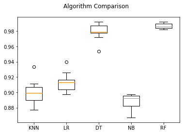

```python
#It show the comparison boxplot graph of various machinelearning algorithms model

from sklearn import model_selection

models = []
models.append(('KNN', KNeighborsClassifier()))
models.append(('LR', LogisticRegression(max_iter=1000)))
models.append(('DT', DecisionTreeClassifier()))
models.append(('NB', GaussianNB()))
models.append(('RF', RandomForestClassifier()))
# evaluate each model in turn
results = []
names = []
scoring = 'accuracy'
for name, model in models:
	kfold = model_selection.KFold(n_splits=10)
	cv_results = model_selection.cross_val_score(model, df_x, df_y, cv=kfold, scoring=scoring)
	results.append(cv_results)
	names.append(name)
	msg = "%s: %f (%f)" % (name, cv_results.mean(), cv_results.std())
	print(msg)
# boxplot algorithm comparison
fig = plt.figure()
fig.suptitle('Algorithm Comparison')
ax = fig.add_subplot(111)
plt.boxplot(results)
ax.set_xticklabels(names)
plt.show()
```

**Conclusion**

The aim of the bank is to convert there liability customers into loan customers. They want to set up a new marketing campaign; hence, they need information about the connection between the variables given in the data. So from six classification algorithms were used in this study. From the above graph , it seems like **Random Forest algorithm** have the highest accuracy and we can choose that as our final model.